# Advanced Visualizations Lecture 02

### 5.3.1 `geom_quasirandom()` adds KDE structure to your plotting

As we can see from above, the `geom_beeswarm()` layer adds a little more structure to the data in a somewhat rigid way. Any datapoints that are near each other are deliberately spaced out to almost represent the distribution of your data. Of course, you may run into some issues as your number of datapoints increases or as your data range increases. We see this problem very clearly in our previous plot.

To remedy this, we can balance the visualization a bit with the `geom_quasirandom()` function. `geom_quasirandom()` works similarly to the `geom_beeswarm()` function with emphasis on an additional method of how the points are plotted:

- `method`: determine the method for distributing the points. Options include:
  - quasirandom, pseudorandom: generates a KDE before plotting points in a violin shape
  - smiley, frowney: generates a KDE, then points are binned with maximum bin values plotted on the outside or inside respectively
  - tukey: plotted more as dotstrips in a box-plot style.
- `varwidth`: if TRUE, vary the width of each group based on the number of samples in the group

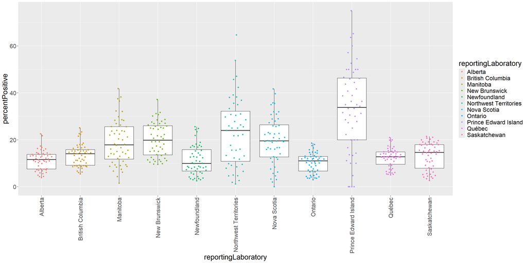

```r
# 5.3.1 Generate a boxplot of EV/RV positivity across provinces with geom_quasirandom

respFinalPop.df %>%
  # Filter for 2024-2025 data
  filter(season %in% c("2024-2025"),
         # Filter out Canada-wide data
         reportingLaboratory != "Canada",
         # Filter for EV/RV
         virus %in% c("EV/RV")
         ) %>%

  # 1. Data
  ggplot(.) +
    # 2. Aesthetics
    aes(x=reportingLaboratory, y = percentPositive) +

    theme(text = element_text(size = 20)) + # set text size
    theme(axis.text.x = element_text(angle=90, hjust = 1, vjust=0.5)) + # Adjust our x-axis text

    # 3. Scaling
    # ylim(0, 80) +

    # 4. Geoms
    geom_boxplot(outlier.shape=NA,  # Remove outliers
                 notch = FALSE) +   ### 5.3.0 Remove the confidence interval notch

    ### 5.3.1 Add datapoints as a quasirandom beeswarm
    geom_quasirandom(width = 0.3, alpha = 0.9, aes(colour = reportingLaboratory))
```

Now our data points take a more nuanced approach with a uniform width that shapes the data as a distribution. We’ll see this with even more emphasis in a few sections.

[figure not shown]

When given the need to show data distribution, try the quasirandom plotting of points over a simple beeswarm.

## 5.4.0 Add a third dimension to your boxplot with nested boxplots

Is there more to the data we’ve visualized? For our dataset, a logical question to ask next would be how do these values compare across different seasons. We’ve done the same previously with our KDE plots so let’s try it with boxplots.

The kind of boxplot we will create are known as nested boxplots. Technically speaking, up to this point, our multi-boxplot visualizations have been “grouped” boxplots because we are exploring a single variable (**percentPositivity**), across multiple groups within another variable (**reportingLaboratory**). Now we will further nest within the `reportingLaboratory`` variable to look at a secondary variable (**season**) to break each province (reporting lab) into subgroups. We could do this with 2 or more seasons but we’ll use just 2 for now.

For our nested boxplot we’ll use the `fill` parameter to generate different subgroups in our boxplot to make a nested boxplot. In doing so, we’ll also have to add the use of the `geom_quasirandom()` parameters:

- `dodge.width`: separate the data points by any aesthetic groups that have been assigned.
- `width`: set the maximum spread of your data points within each grouping
- `alpha`: set the opacity of your data points so you can see more of the overlapping data.

Remember how we said to avoid plotting all points when you have too many? In this case, we can plot all of our points in a cleaner way than `geom_jitter()` by using a `geom_quasirandom()` to confine all our datapoints to a smaller area.

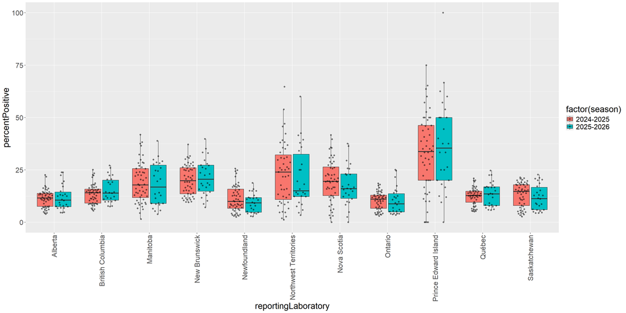

```r
# 5.4.0 Generate a nested boxplot

respFinalPop.df %>%
  # Filter for 2024-2026 data
  filter(season %in% c("2024-2025", "2025-2026"),
         # Filter out Canada-wide data
         reportingLaboratory != "Canada",
         # Filter for EV/RV
         virus %in% c("EV/RV")
         ) %>%

  # 1. Data
  ggplot(.) +
    # 2. Aesthetics
    aes(x=reportingLaboratory,
        y = percentPositive,
        fill = factor(season)                ### 5.4.0 Set the fill colour based on season!
        ) +

    theme(text = element_text(size = 20)) + # set text size
    theme(axis.text.x = element_text(angle=90, hjust = 1, vjust=0.5)) + # Adjust our x-axis text

    # 4. Geoms
    geom_boxplot(outlier.shape=NA,
                 notch = FALSE) +

    ### 5.4.0 Add datapoints as a quasirandom beeswarm
    geom_quasirandom(dodge.width = 0.7,     # How far apart to set our groups
                     width = 0.15,          # How wide to make each beeswarm
                     alpha = 0.5)          # Set the opacity very low since we expect a lot of points!
```

## 5.5.0 Violin plot - the lovechild of density and boxplots

As the title says, the violin plot is a mixture of both the boxplot and kernel density plot. It’s a miniaturized KDE that is mirrored across its axis. It encompasses the summary information of the boxplot but in a pear or violin-shaped distribution. To generate a `geom_violin()` in `ggplot`, a minimum of three values are required. To justify using a violin, I would again suggest sticking to a similar rule of thumb of a minimum ~30 samples/observations to ensure an accurate representation of the distribution.

The nuanced visualization of a violin plot gives much more information than the boxplot itself and most boxplots can be replaced with a violin plot. Despite the gateway to more detailed distribution information, this format remains less popular/familiar to scientists. Therefore its immediate accessibility to your audience can be limited.

An important parameter of this geom is `scale`: this sets how big each violin is in comparison to each other. It accepts the following values:

- `area`: default value so all violins will have the same area.
- `count`: scale areas proportionately to observations.
- `width`: all violins have the same maximum width. Total area is not the same for each.

**Outliers and violins:** Much like a KDE, the theoretical distribution of a violin plot can generate some impossible values - especially at the tails. Remember that this is a theoretical distribution based on the data supplied. Depending on how much variation is in your data, and how many outliers it has, it can really affect the shape of your violin.

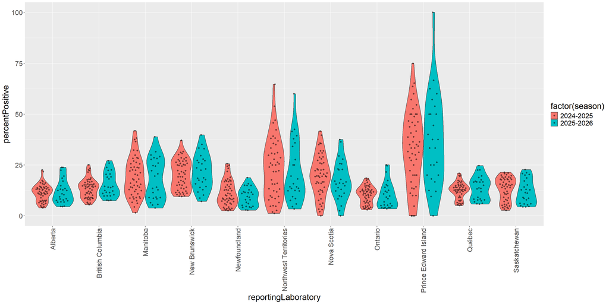

```r
# 5.5.0 Generate a violin plot

respFinalPop.df %>%
  # Filter for 2024-2026 data
  filter(season %in% c("2024-2025", "2025-2026"),
         # Filter out Canada-wide data
         reportingLaboratory != "Canada",
         # Filter for EV/RV
         virus %in% c("EV/RV")
         ) %>%

  # 1. Data
  ggplot(.) +
    # 2. Aesthetics
    aes(x=reportingLaboratory,
        y = percentPositive,
        fill = factor(season)                 ### 5.4.0 Set the fill colour based on season!
        ) +

    theme(text = element_text(size = 20)) + # set text size
    theme(axis.text.x = element_text(angle=90, hjust = 1, vjust=0.5)) + # Adjust our x-axis text

    # 3. Scaling
    # ylim(0, 80) +

    # 4. Geoms
    ### 5.5.0 Add the violin geom
    geom_violin(scale = "width") +

    ### Add datapoints as a quasirandom beeswarm
    geom_quasirandom(dodge.width = 0.85,     # How far apart to set our groups
                     width = 0.15,          # How wide to make each beeswarm
                     alpha = 0.5)          # Set the opacity very low since we expect a lot of points!
```

Looking at our violin plot we can see just how closely the `geom_quasirandom()` points match our violin shape. Depending on the density of your observations, you could easily drop the data points to make things a little cleaner.

## 5.6.0 Violin plots represent distributions and boxplots summarize them

The major advantage to the violin plot is that, by it’s nature, it is very sensitive to the distribution that produces the density estimate. The boxplot represents the summary information of a distribution but is *always* a visual representation of a *normal* distribution. There are not enough parameters supplied to represent anything more complex!

The violin plot is not limited in that respect. Despite some of it’s visual caveats, it can certainly detect *multi-modal* data. Let’s make a toy example to illustrate using some data that we’ll artificially put together.

```
## Orientation inferred to be along y-axis; override with
## `position_quasirandom(orientation = 'x')`
```

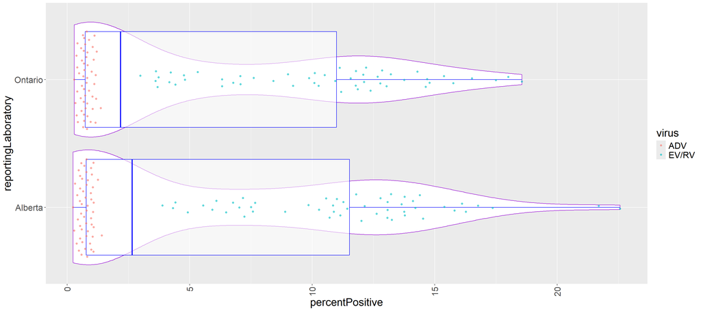

```r
# 5.6.0 Generate a combined violin and boxplot of bimodal data

respFinalPop.df %>%
  # Filter for 2024-2025 data
  filter(season %in% c("2024-2025"),
         # Filter for Ontario and Alberta only
         reportingLaboratory %in% c("Ontario", "Alberta"),
         # Filter for EV/RV
         virus %in% c("EV/RV", "ADV")
         ) %>%

  # 1. Data
  ggplot(.) +
    # 2. Aesthetics
    aes(x=percentPositive,
        y = reportingLaboratory
        ) +

    theme(text = element_text(size = 20)) + # set text size
    theme(axis.text.x = element_text(angle=90, hjust = 1, vjust=0.5)) + # Adjust our x-axis text

    # 3. Scaling
    # ylim(0, 80) +

    # 4. Geoms
    geom_violin(scale = "width", colour="darkviolet") +
    geom_boxplot(alpha = 0.6, colour = "blue") +
    geom_quasirandom(alpha = 0.6, aes(colour = virus))
```

In our toy model, we can see that there really are 2 distinct populations. The datapoints and violins both mirror this. However, looking closely at the boxplot, we only see a long distribution of the data. The biggest tell is the imbalanced upper and lower quartiles of the boxes. Without plotting the datapoints, you would not know if the data is spread evenly over the boxplot’s area (remember it contains the middle 50% of the data) or if it is hiding a bimodal distribution.

**Take-home message:** while boxplots are great and easy to interpret on the surface, always ask to see the datapoints or a violin instead!

## 5.7.0 Combine violin and boxplots into the ultimate plot

From our above example, you can see that we blended a number of `geoms` together. With a little working around, we can also plot both violins and boxplots together in a multivariate setting! This gives us the familiarity of the boxplot but also clearly displays the theoretical distribution. Some steps to accomplish this:

1. To put emphasis on the violin plots we set the `scale` parameter to “width”.
2. We need to adjust some of the boxplot parameters to fit them within the violin plots
3. Some adjustments to the `aes()` parameters for our geoms directly to ensure our points are plotted correctly.
4. Drop the `geom_quasirandom()` layer since our violins mirror the same shape so well.

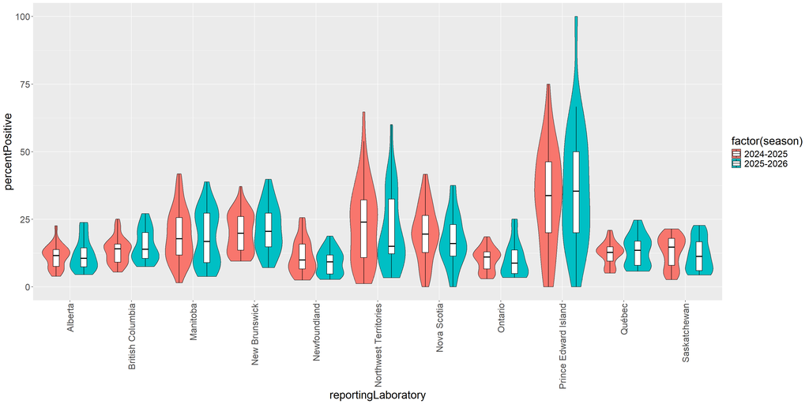

```r
# 5.7.0 Generate a combination violin plot with boxplot

respFinalPop.df %>%
  # Filter for 2024-2026 data
  filter(season %in% c("2024-2025", "2025-2026"),
         # Filter out Canada-wide data
         reportingLaboratory != "Canada",
         # Filter for EV/RV
         virus %in% c("EV/RV")
         ) %>%

  # 1. Data
  ggplot(.) +
    # 2. Aesthetics
    aes(x=reportingLaboratory,
        y = percentPositive) +

    theme(text = element_text(size = 20)) + # set text size
    theme(axis.text.x = element_text(angle=90, hjust = 1, vjust=0.5)) + # Adjust our x-axis text

    # 3. Scaling
    scale_colour_manual(values=c("black", "black")) + # we'll need this to fix our boxplots

    # 4. Geoms
    ### 5.7.0 Add the violin geom
    geom_violin(scale = "width", aes(fill = factor(season))) +

    ### 5.7.0 Boxplot but smaller width so they reside "within" the violin plot.
    # Do you think the order matters?
    geom_boxplot(aes(colour = factor(season)), width=0.2,
                 position = position_dodge(width=0.9),
                 outlier.shape=NA) # Remove the outliers
```

**Section 5.7.0 Comprehension Question:** Looking at the above code for our graph, why do you think we set the **aes(fill/colour = factor(season))** aesthetic individually for some layers rather than directly in the top **aes()** layer?

## 5.8.0 Parallel coordinate plots can help visualize multivariate date

While the above visualization shows with some clarity the total distribution EV/RV positivity across provinces, the messiness of outliers has invaded into some of the violin plots themselves. An experienced eye, however can still see that the bulk of the population centres around our internal boxplots offset by the stretched out look of our violins. We could, of course clean it up by removing some of the outliers ahead of time but I generally keep outliers as a visual reminder that experiments aren’t perfect!

Suppose, however, we wanted to add more viruses to our data across a larger timespan like multiple seasons? With so many potential datapoints in each province, things would start to get very crowded. To accommodate all of that data, you could facet it into multiple groups based on the virus, for instance, but this would separate the datasets from each other. Sometimes things look sharper when you can see it all on a single plot.

Organizing multiple groups, across multiple categories is the domain of the parallel coordinate plot. To accomplish this feat we’ll need to do a couple of key things:

1. We’ll need to group and summarize our data after filtering. We’ll gather the mean positivity for each virus (within a province) at each season.
2. Set a `group` parameter made from multiple variables. Normally, the `group` parameter can only be set to a single variable (column) in your data. We can, however, make a new variable “on the fly” using the `interaction()` function. We can supply *multiple* variables from our dataset to help create this new interaction group. This is an extremely helpful way to subgroup your data much like using a `group_by()` call within the `gpplot()` function.

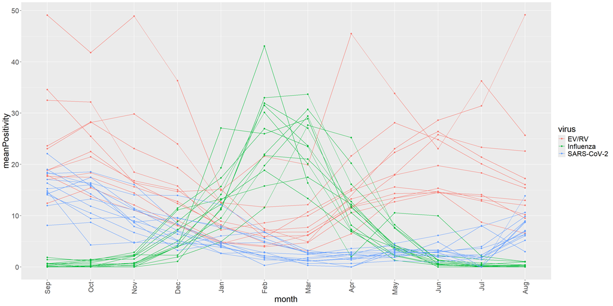

```r
# 5.8.0 Generate a parallel coordinate plot

respFinalPop.df %>%
  # Filter out Canada-wide data
  filter(reportingLaboratory != "Canada",
         season %in% c("2024-2025"),
         # Filter for 3 specific viruses
         virus %in% c("EV/RV", "SARS-CoV-2", "Influenza")
         ) %>%

  # Reset the factors for month to follow the season start and end
  mutate(month = factor(month, levels = c("Sep", "Oct", "Nov", "Dec", "Jan",
                        "Feb", "Mar", "Apr", "May", "Jun", "Jul", "Aug"))) %>%
  # Group the data
  group_by(month, virus, reportingLaboratory) %>%

  # Summarise to get mean positivity for each group
  summarize(meanPositivity = mean(percentPositive)) %>%

  # Revert back to a regular data frame
  ungroup() %>%

  # 1. Data
  ggplot(.) +
    # 2. Aesthetics
    aes(x=month, y = meanPositivity, colour = virus) +

    # Set some configurations for the plot
    theme(text = element_text(size = 20)) + # set text size
    theme(axis.text.x = element_text(angle=90, hjust = 1, vjust=0.5)) + # Adjust our x-axis text

    # 3. Scaling
    # ylim(100000, 200000) +

    # 4. Geoms
    ### 5.8.0 A line plot to join the points
    geom_line(aes(group = interaction(virus, reportingLaboratory))) +    # Set the group aesthetic by a dual-variable set

    ### 5.8.0 Add the points in also to help follow the connections
    geom_point()
```

What our plot does here is connect each month across time, showing the mean positivity for each province which can give us a sense of trend for a single province, but lines are coloured based on `virus` so that we can also see trends between our 3 viral groups. For instance, in 2024-25, the influenza positivity peaked some time between February and March. We could just as easily use the same kind of plot to look at influenza across multiple seasons to ask if it shared a similar trend.

## 5.9.0 Explore the trends within groups after exploring data across groups

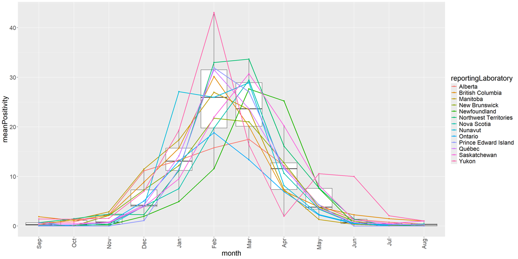

```r
# 5.9.0 Generate a boxplot with a parallel coordinate plot

respFinalPop.df %>%
  filter(reportingLaboratory != "Canada",
         season %in% c("2024-2025"),
         # Filter for just influenza
         virus %in% c("Influenza")
         ) %>%

  # Reset the factors for month to follow the season start and end
  mutate(month = factor(month, levels = c("Sep", "Oct", "Nov", "Dec", "Jan",
                        "Feb", "Mar", "Apr", "May", "Jun", "Jul", "Aug"))) %>%

  group_by(month, reportingLaboratory) %>%

  # Summarise to get mean positivity for each group
  summarize(meanPositivity = mean(percentPositive)) %>%

  # Revert back to a regular data frame
  ungroup() %>%

  # 1. Data
  ggplot(.) +
    # 2. Aesthetics
    aes(x=month, y = meanPositivity) +

    # Set some configurations for the plot
    theme(text = element_text(size = 20)) + # set text size
    theme(axis.text.x = element_text(angle=90, hjust = 1, vjust=0.5)) + # Adjust our x-axis text

    # 4. Geoms
    geom_boxplot(outlier.shape = NA) +

    ### 5.9.0 Add datapoints like a strip plot
    geom_point(aes(colour = reportingLaboratory)) +

    ### 5.9.0 Use a line plot and link our points by numericID
    geom_line(aes(group = reportingLaboratory,
                  colour = reportingLaboratory), linewidth = 1)
```

Surprisingly, it looks like Ontario and Alberta have some of the lowest peaks for 2024-2025. Newfoundland appears to peak slightly later while Yukon appears to have the highest rate, peaking in February with a small resurgence in May/June.

# 6.0.0 Class summary

We’ve covered a number of key plots today, including when and how to use them. Next week we’ll revisit some of these plots and spruce them up with extra touches that will take them that extra distance. Below you’ll find a summary of what we’ve discussed today.

## 6.1.0 Summary of plots

| Plot | Key Features | Notes |
| --- | --- | --- |
| Scatterplot | Good for exploring relationships between variables | Bubbleplots add an extra dimension to your data |
| Barplot | Present values across groups. | Presenting proportions, small sample sizes |
|  | Stack categories for extra dimension | Does not dissect individual distributions |
| Nightingale plot | Circular-wedge barplot, same properties as barplot | Presenting data over unordered groups |
|  |  | Visual emphasis on outer area size may mislead reader |
| Racetrack plot | Circular-ringed barplot, same properties as barplot | Looking for a more compact way to show barplots |
|  |  | Calculate length by radians as outer rings are “stretched” |
| Density plot | Theoretical distribution of your sample data | Minimum sample size 4 but 30 is more reliable |
|  |  | Can plot up to 5 distributions on same axis |
|  |  | Tails can produce “ghost” data |
| Ridgeplots | Allows tighter visualizations of multiple densities | Good way to pack more KDEs into a smaller area |
|  | Same properties as KDEs | No real control of outliers |
|  |  | Similar “ghost” data issues |
| Box and whisker plot | Summarize distributions with 5 parameters | Popular and compact presentation of simple populations |
|  |  | Minimum sample size = 5 |
|  |  | Does not properly visualize multi-modal data |
| Violin plots | Boxplot format with KDE violin shape | Compact representation of distribution shape |
|  |  | Less popular with nuanced interpretation |
|  |  | Inherits “ghost” data and other properties of KDE |
|  |  | DOES interpret multi-modal populations |
| Parallel coordinate plot | Visual representation of multivariate data | Connects trends across groups |
|  | Related data can be connected linearly | Not limited by number of samples |
|  |  | Can help identify trends within multicategorical data |

## 6.2.0 Weekly assignment

This week’s assignment will be found under the current lecture folder under the “assignment” subfolder. It will include an R markdown notebook that you will use to produce the code and answers for this week’s assignment. Please provide answers in markdown or code cells that immediately follow each question section.

|  | Assignment breakdown |  |
| --- | --- | --- |
| Code | 50% | - Does it follow best practices? |
|  |  | - Does it make good use of available packages? |
|  |  | - Was data prepared properly |
| Answers and Output | 50% | - Is output based on the correct dataset? |
|  |  | - Are groupings appropriate |
|  |  | - Are correct titles/axes/legends correct? |
|  |  | - Is interpretation of the graphs correct? |

Since coding styles and solutions can differ, students are encouraged to use best practices. Assignments *may* be rewarded for well-coded or elegant solutions.

## 6.3.0 Acknowledgements

**Revision 1.0.0**: created and prepared for **CSB1021H S LEC0141**, 03-2021 by Calvin Mok, Ph.D. *Bioinformatician, Education and Outreach, CAGEF.*

**Revision 1.0.1**: edited and prepared for **CSB1020H S LEC0141**, 03-2022 by Calvin Mok, Ph.D. *Bioinformatician, Education and Outreach, CAGEF.*

**Revision 1.0.2**: edited and prepared for **CSB1020H S LEC0141**, 03-2023 by Calvin Mok, Ph.D. *Bioinformatician, Education and Outreach, CAGEF.*

**Revision 2.0.0**: Revised and prepared for **CSB1020H S LEC0141**, 03-2024 by Calvin Mok, Ph.D. *Bioinformatician, Education and Outreach, CAGEF.*

**Revision 3.0.0**: Revised and prepared for **CSB1020H S LEC0141**, 03-2025 by Calvin Mok, Ph.D. *Bioinformatician, Education and Outreach, CAGEF.*

**Revision 4.0.0**: Revised and prepared for **CSB1020H S LEC0141**, 03-2026 by Calvin Mok, Ph.D. *Bioinformatician, Education and Outreach, CAGEF.*

## 6.4.0 References

1. Public Ontario Salary Data: https://www.ontario.ca/page/public-sector-salary-disclosure
2. Anscombe’s Quartet: https://en.wikipedia.org/wiki/Anscombe%27s_quartet
3. Choosing the right chart type: https://extremepresentation.typepad.com/blog/2006/09/choosing_a_good.html
4. A layered grammar of graphics by Hadley Wickham: http://vita.had.co.nz/papers/layered-grammar.html
5. `read_delim()` column types and information: https://readr.tidyverse.org/reference/read_delim.html
6. Pie chart rules: https://www.1ka.si/d/en/help/faq/what-is-the-maximum-number-of-categories-to-display-using-pie-charts
7. Kernel density estimation: https://stats.stackexchange.com/questions/76948/what-is-the-minimum-number-of-data-points-required-for-kernel-density-estimation
8. Ridgeline plots: https://www.data-to-viz.com/graph/ridgeline.html
9. Visualizing samples with boxplots: https://www.nature.com/articles/nmeth.2813.pdf?origin=ppub#:~:text=Whereas%20histograms%20require%20a%20sample,render%20it%20even%20more%20informative.
10. Reasons to use a violin plot: https://blog.bioturing.com/2018/05/16/5-reasons-you-should-use-a-violin-graph/
11. Parallel coordinate plot parameters: https://www.rdocumentation.org/packages/GGally/versions/1.5.0/topics/ggparcoord
12. Lots of more plots in R!: https://www.r-graph-gallery.com/index.html

## The Center for the Analysis of Genome Evolution and Function (CAGEF)

The Centre for the Analysis of Genome Evolution and Function (CAGEF) at the University of Toronto offers comprehensive experimental design, research, and analysis services in microbiome and metagenomic studies, genomics, proteomics, and bioinformatics.

From targeted DNA amplicon sequencing to transcriptomes, whole genomes, and metagenomes, from protein identification to post-translational modification, CAGEF has the tools and knowledge to support your research. Our state-of-the-art facility and experienced research staff provide a broad range of services, including both standard analyses and techniques developed by our team. In particular, we have special expertise in microbial, plant, and environmental systems.

For more information about us and the services we offer, please visit https://www.cagef.utoronto.ca/.

[figure not shown]